# How people learn to code

Surabhi Chouhan

December 25, 2016

# Demographics

Some basic demographics: gender and age mix

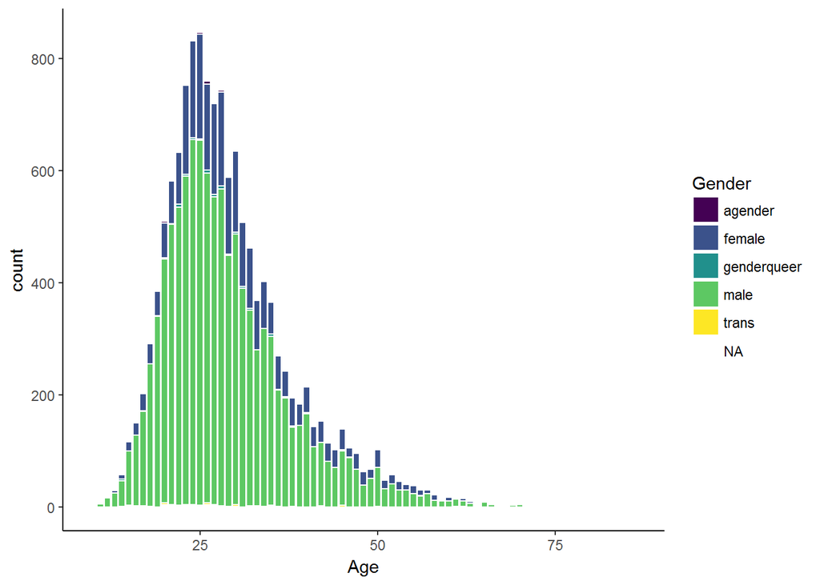

The surveyed has median age of 27, more male than female

Let’s see if the gender mix change across ages

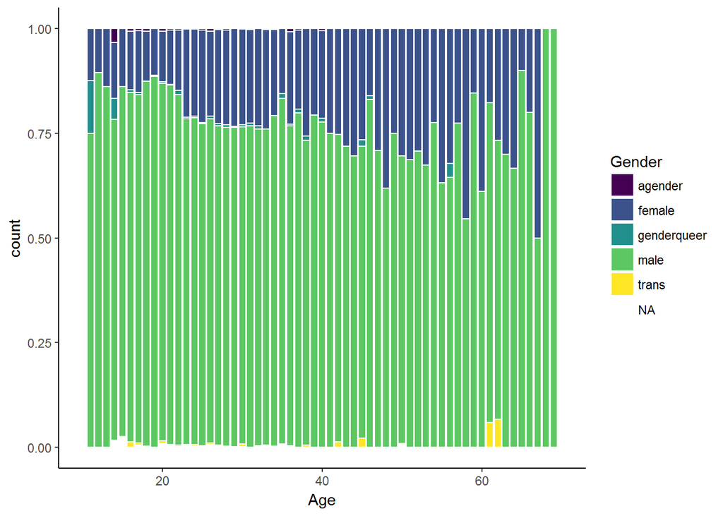

There are increasing percentage of older female coding.

What are the top countries people live in

| CountryLive | less than 100,000 | between 100,000 and 1 million | more than 1 million |
| --- | --- | --- | --- |
| Australia | 23 | 65 | 172 |
| Brazil | 39 | 75 | 153 |
| Canada | 87 | 216 | 233 |
| India | 65 | 296 | 604 |
| United Kingdom | 180 | 226 | 204 |
| United States of America | 1758 | 2476 | 1971 |

# Socio-economic profile

In terms of hours of learning, how are people of different income group behave differently?

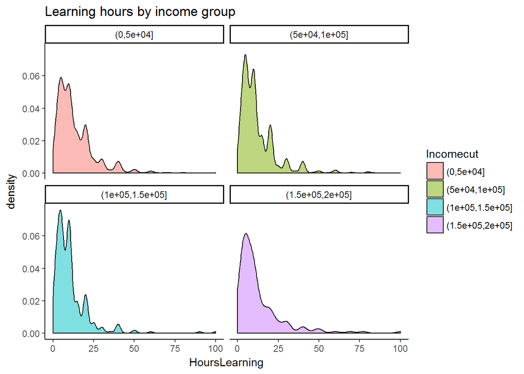

# Career

67 % of those attended bootcamp finished them. 58 % of those finish bootcamp had full-time job afterwards.

What are the job fields and employment status for participant

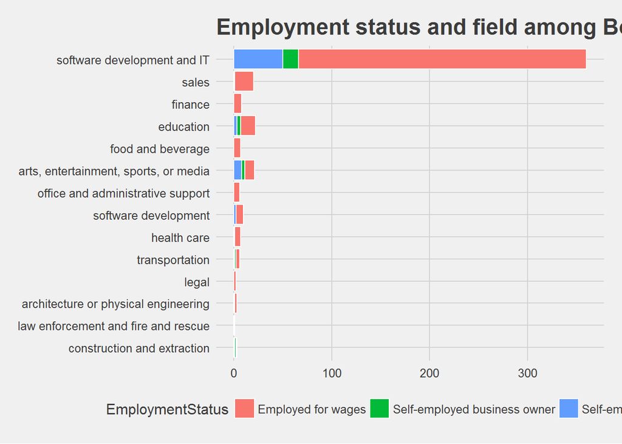

Majority are employed for wages and working in software development and IT. Participants also come from in sales, education, finance, media etc.

Next we’ll how are people’s current job differ from their ideal job

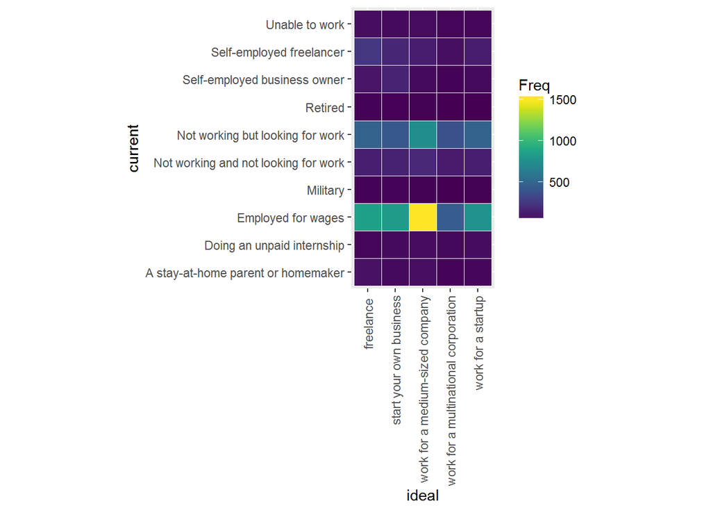

So lots of people employeed for wages want changes, either work for a medium-sized company, or start-up, freelance, etc

# Online Resources for learning coding

Let’s see what resources they use to learn online

| name | count |
| --- | --- |
| FCC | 10937 |
| Codecademy | 9586 |
| Coursera | 4844 |
| Udemy | 4130 |
| KhanAcademy | 3746 |
| PluralSight | 3565 |
| EdX | 3472 |
| Udacity | 3306 |
| OdinProj | 1687 |
| CodeWars | 1563 |
| DevTips | 968 |
| Treehouse | 422 |
| StackOverflow | 191 |
| Lynda | 150 |
| Books | 144 |
| W3Schools | 121 |
| YouTube | 121 |
| Google | 55 |
| SkillCrush | 36 |
| Blogs | 30 |
| HackerRank | 30 |
| SoloLearn | 30 |
| EggHead | 29 |
| Reddit | 29 |
| MDN | 26 |

It appears Freecodecamp, Codeacademy, Udemy, Udacity, Coursera, Edx, Khan Academy and PluralSight are among popular resources

# Coding Events

Next let’s see what Code events people join

| name | count |
| --- | --- |
| None | 8900 |
| Conferences | 2898 |
| Hackathons | 2422 |
| Coffee | 2077 |
| StartUpWknd | 743 |
| WomenCode | 711 |
| GirlDev | 558 |
| NodeSchool | 480 |
| Meetup | 313 |
| RailsBridge | 255 |
| Bootcamp | 42 |
| Workshop | 23 |
| GameJam | 22 |
| DjangoGirls | 18 |
| RailsGirls | 14 |

It appears conference, coffee and hackathon are among the top code events.

# Coding podcast

What podcast do they listen to?

| name | count |
| --- | --- |
| None | 11040 |
| CodeNewbie | 1878 |
| JSJabber | 1356 |
| SEDaily | 775 |
| ChangeLog | 583 |
| ShopTalk | 83 |
| DeveloperTea | 80 |
| RubyRogues | 79 |
| TalkPython | 41 |
| ProgrammingThrowDown | 34 |
| JsAir | 29 |
| Hanselminutes | 19 |
| DotNetRocks | 18 |
| CodingBlocks | 16 |
| WebAhead | 15 |

JS Jabber, Code Newbie and SE Daily sounds fun

# Bootcamp

What are the bootcamps people attend and do people recommend it

| BootcampName | recommendpct | attendee |
| --- | --- | --- |
| General Assembly | 0 | 90 |
| Flatiron School | 0 | 54 |
| Dev Bootcamp | 0 | 48 |
| The Iron Yard | 0 | 40 |
| Prime Digital Academy | 0 | 30 |
| Hack Reactor | 0 | 29 |
| Turing | 0 | 27 |
| App Academy | 0 | 22 |
| Hackbright Academy | 0 | 22 |
| Code Fellows | 0 | 21 |
| Bloc.io | 0 | 21 |
| MakerSquare | 0 | 20 |
| New York Code + Design Academy | 0 | 20 |
| Galvanize | 0 | 20 |
| Coding Dojo | 0 | 18 |
| The Firehose Project | 0 | 16 |
| Epicodus | 0 | 14 |
| Dev Academy | 0 | 13 |
| Makers Academy | 0 | 12 |
| Tech Talent South | 0 | 12 |
| Coder Camps | 0 | 11 |
| Viking Code School | 0 | 10 |
| DevMountain | 0 | 10 |
| Launch Academy | 0 | 10 |
| Software Guild | 0 | 10 |
| Codeup | 0 | 10 |
| Ada | 0 | 9 |
| CodeaCamp | 0 | 8 |
| Anyone Can Learn To Code | 0 | 7 |
| CodeNinja | 0 | 7 |

[output cut: 94 more lines]